# Analysis Plan

#### Questions

You are flying with a friend who has upgraded their ticket to business class and has two coupons, each worth $35, which can be used to upgrade your ticket/seat from economy to business class. They purchased one coupon for the standard price of $35 and received the other one for free. Just one coupon is required to upgrade your class on the current flight, and your friend offers you the coupon [which he purchased / which he got for free] so that you can upgrade as well.

What do you think is the most appropriate thing to do? a) Pay your friend $35 for the coupon. b) Consider it a gift and not pay for the coupon. c) Pay some, but not the full amount for the coupon (for example, half the price).

#### Stan Code

```
data {
  int<lower=1> N;  // total number of observations
  int Y[N];  // response variable
  int<lower=1> K;  // number of population-level effects
  matrix[N, K] X;  // population-level design matrix

  int prior_only;  // should the likelihood be ignored?
}

parameters {
  vector[K] b;  // population-level effects
}

transformed parameters {
}

model {
  // likelihood including constants
  if (!prior_only) {
    vector[N] mu = X * b;
    target += bernoulli_logit_lpmf(Y | mu);
  }
  // priors including constants
  target += normal_lpdf(b | 0, 5);
}
```

#### Fit

```r
# Create Stan Data
  X <- model.matrix(~ coupon, data_s7)

  #Stan Data
  stan_data <- list(
    N = nrow(data_s7),
    Y = data_s7$response,
    X = X,
    K = ncol(X),

    N_sbj    = n_sbj,
    J_sbj    = data_s7$subject,

    prior_only = 0
  )

  # Fit the model
  fit_S7 <- rstan::sampling(bernoulli_scenario_6,
                            iter = 2000,
                            cores = 4,
                            pars    = c('b'),
                            save_warmup = FALSE,
                            data = stan_data,
                            save_warmup = FALSE)
```

**Plot Model Posteriors**

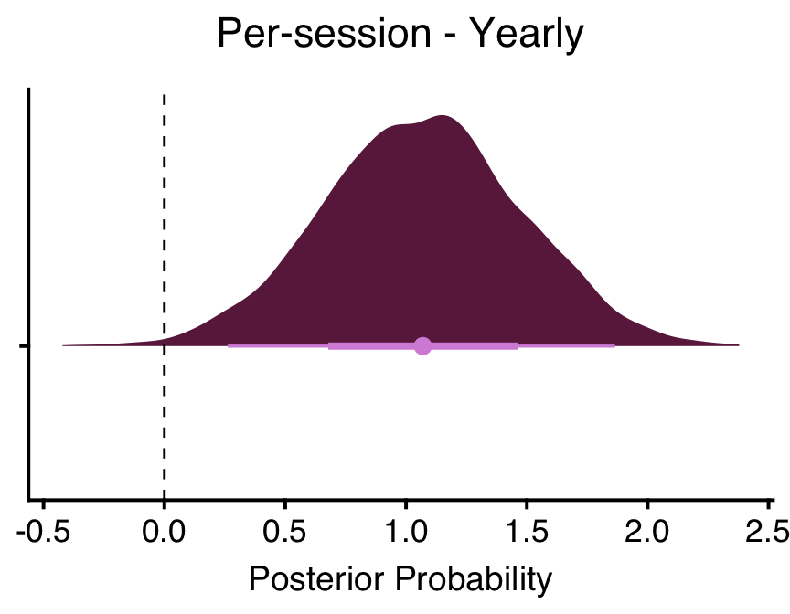

```r
extract(fit_S7)$b %>%
    as.data.frame() %>%
    mutate(post = V2, type = "") %>%
    ggplot(aes(x = post, y = type)) + stat_halfeye(fill = jcolors::jcolors(palette = "pal8")[6],
    color = jcolors::jcolors(palette = "pal8")[12]) + mytheme() + geom_vline(xintercept = 0,
    linetype = 2) + labs(y = NULL, x = "Posterior Probability", title = "Per-session - Yearly")
```